# Assignment

Thomas Lyle (u3236563)

2024-03-30

# Data Creation

```r
# Set the seed for reproducibility
set.seed(123)

# Create a sequence of dates for the month of March 2023
dates <- seq(from = as.Date("2023-03-01"), to = as.Date("2023-05-31"), by = 1)

# Create a data frame to store the weather data
weather <- data.frame(
  Date = dates,
  Temperature = round(runif(length(dates), 15, 25), 1),
  Humidity = sample(50:100, length(dates), replace = TRUE),
  Pressure = sample(995:1015, length(dates), replace = TRUE),
  WindSpeed = sample(5:20, length(dates), replace = TRUE),
  WindDirection = sample(c("N", "NE", "E", "SE", "S", "SW", "W", "NW"), length(dates), replace = TRUE),
  DewPoint = round(runif(length(dates), 10, 15), 1),
  CloudCover = sample(0:100, length(dates), replace = TRUE),
  Precipitation = round(runif(length(dates), 0, 15), 1),
  Visibility = sample(5:20, length(dates), replace = TRUE),
  UVIndex = sample(1:5, length(dates), replace = TRUE),
  Condition = sample(c("Sunny", "Partly Cloudy", "Rainy", "Snowy"), length(dates), replace = TRUE),
  Location = rep(c("Sydney", "Canberra"), each = length(dates)/2)
)
```

# Part A: Data Understanding

This data set has weather data from Sydney and Canberra, describing different components of the weather. This data can be useful in creating models to predict weather in the months March through to the end of May. The data should only really be used to compare for this time frame, as some trends will not account for changes in season, and could assume a linear relationship where the temperature will continue to decline, rather than oscillate as the seasons change. This is because the data is only over a three month period, leaving a lot of missing context.

Using the data, we can try to find a relationship between the different variables and then are able to make predictions about those attributes. By using some analysis, we can find the important factors that relate a lot of these variables together, making it easier to model with less information. If possible, we can make a model that uses very few data points to predict what the weather will be like on any given day in the future.

Since the data is separated into Sydney and Canberra, it is best to separate the data from each other, so that a true reading can be given. Using the `summary()` function to find some high-level statistics about the data, we get the following output:

```r
# Sydney data
sydney.indices <- which(weather$Location == "Sydney")
sydney.data <- weather[sydney.indices,]

# Canberra data
canberra.indices <- which(weather$Location == "Canberra")
canberra.data <- weather[canberra.indices,]

# Summary Sydney
summary(sydney.data)
```

```
##       Date             Temperature       Humidity         Pressure
##  Min.   :2023-03-01   Min.   :15.20   Min.   : 52.00   Min.   : 995
##  1st Qu.:2023-03-12   1st Qu.:17.90   1st Qu.: 64.50   1st Qu.:1002
##  Median :2023-03-23   Median :20.35   Median : 78.50   Median :1005
##  Mean   :2023-03-23   Mean   :20.25   Mean   : 77.02   Mean   :1006
##  3rd Qu.:2023-04-03   3rd Qu.:22.82   3rd Qu.: 88.25   3rd Qu.:1010
##  Max.   :2023-04-15   Max.   :24.90   Max.   :100.00   Max.   :1015
##    WindSpeed     WindDirection         DewPoint       CloudCover
##  Min.   : 5.00   Length:46          Min.   :10.10   Min.   : 1.00
##  1st Qu.: 7.00   Class :character   1st Qu.:11.93   1st Qu.:33.50
##  Median :12.00   Mode  :character   Median :12.80   Median :55.50
##  Mean   :12.13                      Mean   :12.79   Mean   :51.39
##  3rd Qu.:17.00                      3rd Qu.:14.00   3rd Qu.:70.75
##  Max.   :20.00                      Max.   :14.80   Max.   :98.00
##  Precipitation      Visibility      UVIndex       Condition
##  Min.   : 0.200   Min.   : 5.0   Min.   :1.000   Length:46
##  1st Qu.: 3.550   1st Qu.: 8.0   1st Qu.:2.000   Class :character
##  Median : 7.350   Median :10.0   Median :2.500   Mode  :character
##  Mean   : 7.096   Mean   :11.2   Mean   :2.696
##  3rd Qu.:10.175   3rd Qu.:14.0   3rd Qu.:3.750
##  Max.   :14.900   Max.   :20.0   Max.   :5.000
##    Location
##  Length:46
##  Class :character
##  Mode  :character
##
##
##
```

```r
#Summary Canberra
summary(canberra.data)
```

```
##       Date             Temperature       Humidity         Pressure
##  Min.   :2023-04-16   Min.   :15.00   Min.   : 50.00   Min.   : 995
##  1st Qu.:2023-04-27   1st Qu.:17.32   1st Qu.: 64.25   1st Qu.:1000
##  Median :2023-05-08   Median :19.45   Median : 75.50   Median :1004
##  Mean   :2023-05-08   Mean   :19.85   Mean   : 76.26   Mean   :1006
##  3rd Qu.:2023-05-19   3rd Qu.:22.50   3rd Qu.: 88.75   3rd Qu.:1011
##  Max.   :2023-05-31   Max.   :24.80   Max.   :100.00   Max.   :1015
##    WindSpeed     WindDirection         DewPoint       CloudCover
##  Min.   : 5.00   Length:46          Min.   :10.10   Min.   :  2.00
##  1st Qu.: 7.25   Class :character   1st Qu.:11.12   1st Qu.: 32.00
##  Median :13.00   Mode  :character   Median :12.55   Median : 55.50
##  Mean   :12.65                      Mean   :12.55   Mean   : 54.65
##  3rd Qu.:17.00                      3rd Qu.:14.10   3rd Qu.: 77.75
##  Max.   :20.00                      Max.   :15.00   Max.   :100.00
##  Precipitation      Visibility       UVIndex       Condition
##  Min.   : 0.100   Min.   : 5.00   Min.   :1.000   Length:46
##  1st Qu.: 3.450   1st Qu.: 9.25   1st Qu.:2.000   Class :character
##  Median : 6.450   Median :13.00   Median :3.000   Mode  :character
##  Mean   : 6.739   Mean   :13.00   Mean   :2.891
##  3rd Qu.:10.375   3rd Qu.:15.75   3rd Qu.:4.000
##  Max.   :14.900   Max.   :20.00   Max.   :5.000
##    Location
##  Length:46
##  Class :character
##  Mode  :character
##
##
##
```

To get an idea of the temperature readings, we can produce a histogram.

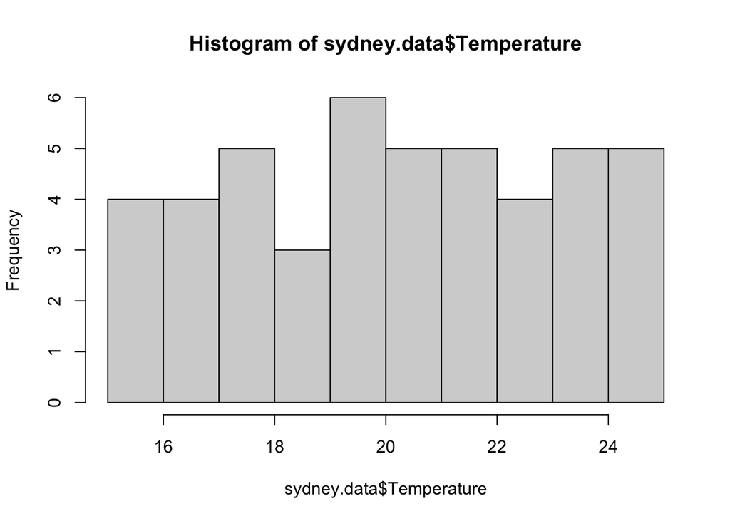

```r
# Histograms
hist(sydney.data$Temperature)
```

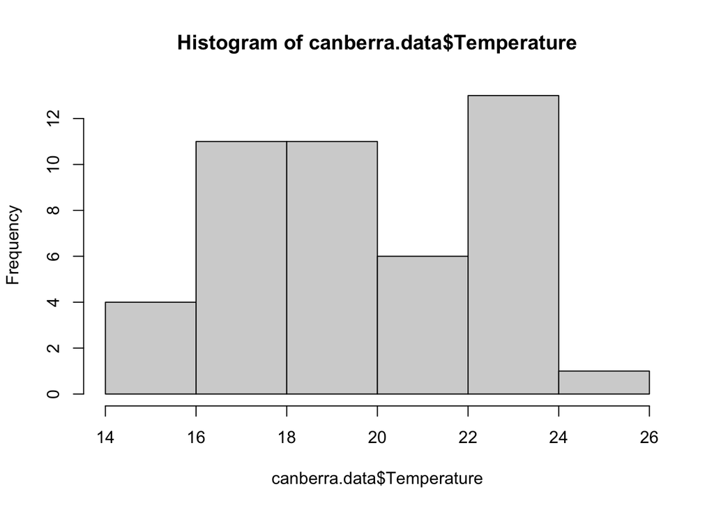

```r
hist(canberra.data$Temperature)
```

This data shows that both cities were mostly similar in temperature, with Canberra having slightly colder weather overall. The temperature reached a minimum of 15 deg Celsius and a maximum of 24.9 deg Celsius, averaging a temperature of about 20 deg Celsius for both cities. The biggest thing to note between these two representations is that the dates stop at April 15th for Sydney and start at April 16th for Canberra.

# Part B: Vector and Matrix Manipulation

To help visualise the data by months, it is useful to create a subset of data for the weather of each month.

```r
weather.march <- weather[which(weather$Date < as.Date("2023-04-01")),]
weather.april <- weather[which((weather$Date < as.Date("2023-05-01")) & (weather$Date >= as.Date("2023-04-01"))),]
weather.may <- weather[which((weather$Date < as.Date("2023-06-01")) & (weather$Date >= as.Date("2023-05-01"))),]
```

Now, determining the average temperature for each month and storing it to a vector:

```r
average_temps <- c(mean(weather.march$Temp), mean(weather.april$Temp), mean(weather.may$Temp))
average_temps
```

```
## [1] 20.84839 19.29000 19.98710
```

Average humidity for each month, divided by location:

```r
# Sydney
sydney.data.march <- sydney.data[which(sydney.data$Date < as.Date("2023-04-01")),]
sydney.data.april <- sydney.data[which(sydney.data$Date >= as.Date("2023-04-01")),]

sydney.humidity.monthly <- c(mean(sydney.data.march$Humidity), mean(sydney.data.april$Humidity))
sydney.humidity.monthly
```

```
## [1] 76.16129 78.80000
```

```r
# Canberra
canberra.data.april <- canberra.data[which(canberra.data$Date < as.Date("2023-05-01")),]
canberra.data.may <- canberra.data[which(canberra.data$Date >= as.Date("2023-05-01")),]

canberra.humidity.monthly <- c(mean(canberra.data.april$Humidity), mean(canberra.data.may$Humidity))
canberra.humidity.monthly
```

```
## [1] 79.60000 74.64516
```

Then, creating a matrix containing the average temperature, humidity, pressure, and wind speed readings for each month:

```r
a.data.march <- c(mean(weather.march$Temperature), mean(weather.march$Humidity), mean(weather.march$Pressure), mean(weather.march$WindSpeed))

a.data.april <- c(mean(weather.april$Temperature), mean(weather.april$Humidity), mean(weather.april$Pressure), mean(weather.april$WindSpeed))

a.data.may <- c(mean(weather.may$Temperature), mean(weather.may$Humidity), mean(weather.may$Pressure), mean(weather.may$WindSpeed))

a.data <- c(a.data.march, a.data.april, a.data.may)
a <- matrix(a.data, 4, 3)
a
```

```
##            [,1]       [,2]       [,3]
## [1,]   20.84839   19.29000   19.98710
## [2,]   76.16129   79.20000   74.64516
## [3,] 1006.22581 1005.16667 1005.87097
## [4,]   11.51613   13.53333   12.16129
```

Now creating another matrix containing the average temperature, humidity, pressure, and wind speed readings for each city:

```r
# For Sydney data

# Get the temp, humidity, pressure and wind speed
b.sydney <- sydney.data[, c("Temperature", "Humidity", "Pressure", "WindSpeed")]

# Divide into months
b.sydney.march <- b.sydney[which(sydney.data$Date < as.Date("2023-04-01")),]
b.sydney.april <- b.sydney[which(sydney.data$Date >= as.Date("2023-04-01")),]

# Find averages
b.sydney.march.average <- unlist(lapply(b.sydney.march, mean), use.names = FALSE)
b.sydney.april.average <- unlist(lapply(b.sydney.april, mean), use.names = FALSE)

b.data <- c(b.sydney.march.average, b.sydney.april.average)
b <- matrix(b.data, 4, 2)

b
```

```
##            [,1]       [,2]
## [1,]   20.84839   19.02667
## [2,]   76.16129   78.80000
## [3,] 1006.22581 1005.20000
## [4,]   11.51613   13.40000
```

Now, creating an array containing the average temperature, humidity, pressure, wind speed, and UV index readings for each day of each month. The easiest way I can think to do this is create a 5 * 1 * n array for all data points.

```r
# For all data:

c.data <- unlist(weather[, c("Temperature", "Humidity", "Pressure", "WindSpeed", "UVIndex")], use.names = FALSE)
c.dmsn <- c(5, 1, 92)
my.array <- array(c.data, c.dmsn)
```

Since the array is too long, it is better to not print all elements.

Next, creating two arrays from the one above, divided by city.

```r
# Sydney
d.data <- c.data[(weather$Location == "Sydney")]
d.dmsn <- c(5, 1, 46)
d.syd <- array(d.data, d.dmsn)

# Canberra
e.data <- c.data[which(weather$Location == "Canberra")]
d.can <- array(e.data, d.dmsn)
```

Finally, use matrix multiplication to calculate the product of the transpose of the matrix in task 3 with the vector in task 1.

```r
t(a) * average_temps
```

```
##          [,1]     [,2]     [,3]     [,4]
## [1,] 434.6552 1587.840 20978.19 240.0927
## [2,] 372.1041 1527.768 19389.66 261.0580
## [3,] 399.4840 1491.940 20104.44 243.0689
```

# Part C - Looping and Conditional Statements

Write a loop that calculates the average pressure reading for each month and stores the results in a vector.

```r
# Extract months from Date column
months <- unique(format(weather$Date, "%m"))

# Empty vector to add values into:
average_pressure <- numeric(length(months))

for (i in 1:length(months)) {
  month_data <- subset(weather, format(Date, "%m") == months[i])
  average_pressure[i] <- mean(month_data$Pressure, na.rm = TRUE)
}

average_pressure
```

```
## [1] 1006.226 1005.167 1005.871
```

Use a conditional statement to determine how many days had a temperature above 25 degrees Celsius in Sydney.

```r
total <- sum(sydney.data$Temperature > 25)

total
```

```
## [1] 0
```

Use a for loop to calculate the average humidity for the days with a temperature below 21 degrees Celsius in Canberra.

```r
# Find total and then divide the total by number of occurences
total <- 0

for (i in 1:length(canberra.data$Temperature)) {
  if (canberra.data$Temperature[i] < 21){
    total <- total + canberra.data$Humidity[i]
  }
}

canberra.average_cold_humid <- total / length(canberra.data$Temperature)
canberra.average_cold_humid
```

```
## [1] 45.73913
```

Use a conditional statement to determine how many days had a UV index reading above 7 in both Canberra and Sydney.

```r
total <- sum(weather$UVIndex > 7)

total
```

```
## [1] 0
```

# Part D - Data Frame Manipulation

Import the 5 files:

```r
library(tidyverse)

file1.name <- "data_for_part_D/201808.csv"
file1 <- read_csv(file1.name, skip = 7)

file2.name <- "data_for_part_D/201809.csv"
file2 <- read_csv(file2.name, skip = 7)

file3.name <- "data_for_part_D/201810.csv"
file3 <- read_csv(file3.name, skip = 7)


file4.name <- "data_for_part_D/201811.csv"
file4 <- read_csv(file4.name, skip = 7)


file5.name <- "data_for_part_D/201812.csv"
file5 <- read_csv(file5.name, skip = 7)

combined <- bind_rows(file1, file2, file3, file4, file5)
```

```r
# Dimensions
dim(combined)
```

```
## [1] 153  21
```

```r
# Structure
for (col in names(combined)) {
  cat("Column:", col, "\n")

  str(combined[[col]])

  summary(combined[[col]])
}
```

```
## Column: Date
##  chr [1:153] "1/08/2018" "2/08/2018" "3/08/2018" "4/08/2018" "5/08/2018" ...
## Column: Minimum temperature
##  num [1:153] 7.6 -3.8 -3.6 3.7 -1 1.2 2.4 2.6 1.6 -2.5 ...
## Column: Maximum temperature
##  num [1:153] 15.4 14.3 19.5 12.8 15 13.7 9.7 12.1 13.7 15.6 ...
## Column: Rainfall (mm)
##  num [1:153] 0 0 0 13.8 0 0 6.6 0 0 0.2 ...
## Column: Evaporation (mm)
##  logi [1:153] NA NA NA NA NA NA ...
## Column: Sunshine (hours)
##  logi [1:153] NA NA NA NA NA NA ...
## Column: Direction of maximum wind gust
##  chr [1:153] "NW" "NNW" "NW" "NNW" "NW" "NW" "WNW" "WNW" "NNW" "NNW" "NW" ...
## Column: Speed of maximum wind gust (km/h)
##  num [1:153] 54 26 72 54 43 61 61 70 30 43 ...
## Column: Time of maximum wind gust
##  'hms' num [1:153] 01:38:00 12:23:00 20:56:00 04:50:00 ...
##  - attr(*, "units")= chr "secs"
## Column: 9am Temperature
##  num [1:153] 10.9 3.3 3.7 7.8 5 9.2 4.9 6.5 6.3 0.5 ...
## Column: 9am relative humidity (%)
##  num [1:153] 54 87 84 77 85 72 90 65 94 99 ...
## Column: 9am cloud amount (oktas)
##  num [1:153] NA 1 NA 8 NA 8 5 8 7 8 ...
## Column: 9am wind direction
##  chr [1:153] "WNW" NA NA "NNW" NA "N" "NW" "NW" "SSW" NA "SE" "W" "NNW" ...
## Column: 9am wind speed (km/h)
##  chr [1:153] "22" "Calm" "Calm" "24" "Calm" "28" "30" "30" "9" "Calm" "7" ...
## Column: 9am MSL pressure (hPa)
##  num [1:153] 1019 1027 1018 1017 1018 ...
## Column: 3pm Temperature
##  num [1:153] 14.7 13.7 17.9 11.6 14.6 10.9 8.8 9.9 12.9 14.9 ...
## Column: 3pm relative humidity (%)
##  num [1:153] 32 43 35 52 48 44 54 60 50 42 ...
## Column: 3pm cloud amount (oktas)
##  num [1:153] NA NA 4 5 NA 8 NA 8 NA NA ...
## Column: 3pm wind direction
##  chr [1:153] "NW" "NE" "NNW" "WNW" "NW" "WNW" "WNW" "WNW" "N" "NW" "NNW" ...
## Column: 3pm wind speed (km/h)
##  num [1:153] 19 9 39 22 24 31 44 35 15 28 ...
## Column: 3pm MSL pressure (hPa)
##  num [1:153] 1019 1022 1010 1016 1012 ...
```

Write a code to remove the variables, which have no data at all (i.e. all the records in these variables are NAs)

```r
# Find columns with all NA values
na_cols <- sapply(combined, function(x) all(is.na(x)))

combined <- combined[, !na_cols]
combined
```

```
## # A tibble: 153 × 19
##    Date       `Minimum temperature` `Maximum temperature` `Rainfall (mm)`
##    <chr>                      <dbl>                 <dbl>           <dbl>
##  1 1/08/2018                    7.6                  15.4             0
##  2 2/08/2018                   -3.8                  14.3             0
##  3 3/08/2018                   -3.6                  19.5             0
##  4 4/08/2018                    3.7                  12.8            13.8
##  5 5/08/2018                   -1                    15               0
##  6 6/08/2018                    1.2                  13.7             0
##  7 7/08/2018                    2.4                   9.7             6.6
##  8 8/08/2018                    2.6                  12.1             0
##  9 9/08/2018                    1.6                  13.7             0
## 10 10/08/2018                  -2.5                  15.6             0.2
## # ℹ 143 more rows
## # ℹ 15 more variables: `Direction of maximum wind gust` <chr>,
## #   `Speed of maximum wind gust (km/h)` <dbl>,
## #   `Time of maximum wind gust` <time>, `9am Temperature` <dbl>,
## #   `9am relative humidity (%)` <dbl>, `9am cloud amount (oktas)` <dbl>,
## #   `9am wind direction` <chr>, `9am wind speed (km/h)` <chr>,
## #   `9am MSL pressure (hPa)` <dbl>, `3pm Temperature` <dbl>, …
```

Write code to change the column names to have no spaces between the words and replace these spaces with underscore the _ character.

```r
names(combined) <- gsub(" ", "_", names(combined))

combined
```

```
## # A tibble: 153 × 19
##    Date       Minimum_temperature Maximum_temperature `Rainfall_(mm)`
##    <chr>                    <dbl>               <dbl>           <dbl>
##  1 1/08/2018                  7.6                15.4             0
##  2 2/08/2018                 -3.8                14.3             0
##  3 3/08/2018                 -3.6                19.5             0
##  4 4/08/2018                  3.7                12.8            13.8
##  5 5/08/2018                 -1                  15               0
##  6 6/08/2018                  1.2                13.7             0
##  7 7/08/2018                  2.4                 9.7             6.6
##  8 8/08/2018                  2.6                12.1             0
##  9 9/08/2018                  1.6                13.7             0
## 10 10/08/2018                -2.5                15.6             0.2
## # ℹ 143 more rows
## # ℹ 15 more variables: Direction_of_maximum_wind_gust <chr>,
## #   `Speed_of_maximum_wind_gust_(km/h)` <dbl>,
## #   Time_of_maximum_wind_gust <time>, `9am_Temperature` <dbl>,
## #   `9am_relative_humidity_(%)` <dbl>, `9am_cloud_amount_(oktas)` <dbl>,
## #   `9am_wind_direction` <chr>, `9am_wind_speed_(km/h)` <chr>,
## #   `9am_MSL_pressure_(hPa)` <dbl>, `3pm_Temperature` <dbl>, …
```

Write code to create two new columns for the month and year from the Date column.

```r
library(lubridate)

combined$Month <- month(combined$Date)
combined$Year <- year(combined$Date)

combined
```

```
## # A tibble: 153 × 21
##    Date       Minimum_temperature Maximum_temperature `Rainfall_(mm)`
##    <chr>                    <dbl>               <dbl>           <dbl>
##  1 1/08/2018                  7.6                15.4             0
##  2 2/08/2018                 -3.8                14.3             0
##  3 3/08/2018                 -3.6                19.5             0
##  4 4/08/2018                  3.7                12.8            13.8
##  5 5/08/2018                 -1                  15               0
##  6 6/08/2018                  1.2                13.7             0
##  7 7/08/2018                  2.4                 9.7             6.6
##  8 8/08/2018                  2.6                12.1             0
##  9 9/08/2018                  1.6                13.7             0
## 10 10/08/2018                -2.5                15.6             0.2
## # ℹ 143 more rows
## # ℹ 17 more variables: Direction_of_maximum_wind_gust <chr>,
## #   `Speed_of_maximum_wind_gust_(km/h)` <dbl>,
## #   Time_of_maximum_wind_gust <time>, `9am_Temperature` <dbl>,
## #   `9am_relative_humidity_(%)` <dbl>, `9am_cloud_amount_(oktas)` <dbl>,
## #   `9am_wind_direction` <chr>, `9am_wind_speed_(km/h)` <chr>,
## #   `9am_MSL_pressure_(hPa)` <dbl>, `3pm_Temperature` <dbl>, …
```

Write code to replace the remaining NAs with the median of the values of each column.

```r
for (col in names(combined)) {
  # Calculate median of non-NA values
  median_val <- median(combined[[col]], na.rm = TRUE)
  # Replace NA values with median
  combined[[col]][is.na(combined[[col]])] <- median_val
}

combined
```

```
## # A tibble: 153 × 21
##    Date       Minimum_temperature Maximum_temperature `Rainfall_(mm)`
##    <chr>                    <dbl>               <dbl>           <dbl>
##  1 1/08/2018                  7.6                15.4             0
##  2 2/08/2018                 -3.8                14.3             0
##  3 3/08/2018                 -3.6                19.5             0
##  4 4/08/2018                  3.7                12.8            13.8
##  5 5/08/2018                 -1                  15               0
##  6 6/08/2018                  1.2                13.7             0
##  7 7/08/2018                  2.4                 9.7             6.6
##  8 8/08/2018                  2.6                12.1             0
##  9 9/08/2018                  1.6                13.7             0
## 10 10/08/2018                -2.5                15.6             0.2
## # ℹ 143 more rows
## # ℹ 17 more variables: Direction_of_maximum_wind_gust <chr>,
## #   `Speed_of_maximum_wind_gust_(km/h)` <dbl>,
## #   Time_of_maximum_wind_gust <time>, `9am_Temperature` <dbl>,
## #   `9am_relative_humidity_(%)` <dbl>, `9am_cloud_amount_(oktas)` <dbl>,
## #   `9am_wind_direction` <chr>, `9am_wind_speed_(km/h)` <chr>,
## #   `9am_MSL_pressure_(hPa)` <dbl>, `3pm_Temperature` <dbl>, …
```

Finally, saving the file as a CSV:

```r
write.table(combined , file = "combined_weather.csv", sep=",", row.names=TRUE)
```